# Final Project Preliminary EDA

Yichen Shi

### Research Question:

“Is life expectancy of a country associated with its happiness?”

```r
rm(list=ls())
library(DataComputing)
library(tidyr)
library(mdsr)
```

### Examine the data source:

- I uses two data: “Life Expectancy Data” and “World happiness report in 2015”. The former one was orginally collected from WHO and the United Nations website from 2000-2015. The latter one was collected and published by the United Nations in 2015.
- The case in life expectancy dataset represents the life expectancy scores and other related factors of each country from year 2000 to 2015. There are total of 2938 cases. There are missing values of population, Hepatitis B and GDP for those less known countries.
- The case in world happiness dataset represents the happiness score and other related scores of each country in 2015. There are total of 158 cases. There are no missing values in this dataset.
- The variables I plan to use are country, year, life expectancy, GDP, schooling in “life expectancy data” and variables country, happiness score and region in “world happiness report”. I then join this two datasets and named it “new_table” for analyzation.

```r
life_expect<-read.csv("Life Expectancy Data.csv")
happiness<- read.csv("World happiness report in 2015.csv")
life_expect%>%
  head(5)
```

|  | Country | Year | Status | Life.expectancy | Adult.Mortality | infant.deaths | Alcohol | percentage.expenditure | Hepatitis.B | Measles | BMI | under.five.deaths | Polio | Total.expenditure | Diphtheria | HIV.AIDS | GDP | Population | thinness..1.19.years | thinness.5.9.years | Income.composition.of.resources | Schooling |
| --- | --- | --- | --- | --- | --- | --- | --- | --- | --- | --- | --- | --- | --- | --- | --- | --- | --- | --- | --- | --- | --- | --- |
| 1 | Afghanistan | 2015 | Developing | 65.0 | 263 | 62 | 0.01 | 71.279624 | 65 | 1154 | 19.1 | 83 | 6 | 8.16 | 65 | 0.1 | 584.25921 | 33736494 | 17.2 | 17.3 | 0.479 | 10.1 |
| 2 | Afghanistan | 2014 | Developing | 59.9 | 271 | 64 | 0.01 | 73.523582 | 62 | 492 | 18.6 | 86 | 58 | 8.18 | 62 | 0.1 | 612.69651 | 327582 | 17.5 | 17.5 | 0.476 | 10.0 |
| 3 | Afghanistan | 2013 | Developing | 59.9 | 268 | 66 | 0.01 | 73.219243 | 64 | 430 | 18.1 | 89 | 62 | 8.13 | 64 | 0.1 | 631.74498 | 31731688 | 17.7 | 17.7 | 0.470 | 9.9 |
| 4 | Afghanistan | 2012 | Developing | 59.5 | 272 | 69 | 0.01 | 78.184215 | 67 | 2787 | 17.6 | 93 | 67 | 8.52 | 67 | 0.1 | 669.95900 | 3696958 | 17.9 | 18.0 | 0.463 | 9.8 |
| 5 | Afghanistan | 2011 | Developing | 59.2 | 275 | 71 | 0.01 | 7.097109 | 68 | 3013 | 17.2 | 97 | 68 | 7.87 | 68 | 0.1 | 63.53723 | 2978599 | 18.2 | 18.2 | 0.454 | 9.5 |

```r
summary(life_expect)
```

```
                Country          Year             Status     Life.expectancy Adult.Mortality
 Afghanistan        :  16   Min.   :2000   Developed : 512   Min.   :36.30   Min.   :  1.0
 Albania            :  16   1st Qu.:2004   Developing:2426   1st Qu.:63.10   1st Qu.: 74.0
 Algeria            :  16   Median :2008                     Median :72.10   Median :144.0
 Angola             :  16   Mean   :2008                     Mean   :69.22   Mean   :164.8
 Antigua and Barbuda:  16   3rd Qu.:2012                     3rd Qu.:75.70   3rd Qu.:228.0
 Argentina          :  16   Max.   :2015                     Max.   :89.00   Max.   :723.0
 (Other)            :2842                                    NA's   :10      NA's   :10
 infant.deaths       Alcohol        percentage.expenditure  Hepatitis.B
 Min.   :   0.0   Min.   : 0.0100   Min.   :    0.000      Min.   : 1.00
 1st Qu.:   0.0   1st Qu.: 0.8775   1st Qu.:    4.685      1st Qu.:77.00
 Median :   3.0   Median : 3.7550   Median :   64.913      Median :92.00
 Mean   :  30.3   Mean   : 4.6029   Mean   :  738.251      Mean   :80.94
 3rd Qu.:  22.0   3rd Qu.: 7.7025   3rd Qu.:  441.534      3rd Qu.:97.00
 Max.   :1800.0   Max.   :17.8700   Max.   :19479.912      Max.   :99.00
                  NA's   :194                              NA's   :553
    Measles              BMI        under.five.deaths     Polio       Total.expenditure
 Min.   :     0.0   Min.   : 1.00   Min.   :   0.00   Min.   : 3.00   Min.   : 0.370
 1st Qu.:     0.0   1st Qu.:19.30   1st Qu.:   0.00   1st Qu.:78.00   1st Qu.: 4.260
 Median :    17.0   Median :43.50   Median :   4.00   Median :93.00   Median : 5.755
 Mean   :  2419.6   Mean   :38.32   Mean   :  42.04   Mean   :82.55   Mean   : 5.938
 3rd Qu.:   360.2   3rd Qu.:56.20   3rd Qu.:  28.00   3rd Qu.:97.00   3rd Qu.: 7.492
 Max.   :212183.0   Max.   :87.30   Max.   :2500.00   Max.   :99.00   Max.   :17.600
                    NA's   :34                        NA's   :19      NA's   :226
   Diphtheria       HIV.AIDS           GDP              Population
 Min.   : 2.00   Min.   : 0.100   Min.   :     1.68   Min.   :3.400e+01
 1st Qu.:78.00   1st Qu.: 0.100   1st Qu.:   463.94   1st Qu.:1.958e+05
 Median :93.00   Median : 0.100   Median :  1766.95   Median :1.387e+06
 Mean   :82.32   Mean   : 1.742   Mean   :  7483.16   Mean   :1.275e+07
 3rd Qu.:97.00   3rd Qu.: 0.800   3rd Qu.:  5910.81   3rd Qu.:7.420e+06
 Max.   :99.00   Max.   :50.600   Max.   :119172.74   Max.   :1.294e+09
 NA's   :19                       NA's   :448         NA's   :652
 thinness..1.19.years thinness.5.9.years Income.composition.of.resources   Schooling
 Min.   : 0.10        Min.   : 0.10      Min.   :0.0000                  Min.   : 0.00
 1st Qu.: 1.60        1st Qu.: 1.50      1st Qu.:0.4930                  1st Qu.:10.10
 Median : 3.30        Median : 3.30      Median :0.6770                  Median :12.30
 Mean   : 4.84        Mean   : 4.87      Mean   :0.6276                  Mean   :11.99
 3rd Qu.: 7.20        3rd Qu.: 7.20      3rd Qu.:0.7790                  3rd Qu.:14.30
 Max.   :27.70        Max.   :28.60      Max.   :0.9480                  Max.   :20.70
 NA's   :34           NA's   :34         NA's   :167                     NA's   :163
```

```r
happiness%>%
  head(5)
```

|  | Country | Region | Happiness.Rank | Happiness.Score | Standard.Error | Economy..GDP.per.Capita. | Family | Health..Life.Expectancy. | Freedom | Trust..Government.Corruption. | Generosity | Dystopia.Residual |
| --- | --- | --- | --- | --- | --- | --- | --- | --- | --- | --- | --- | --- |
| 1 | Switzerland | Western Europe | 1 | 7.587 | 0.03411 | 1.39651 | 1.34951 | 0.94143 | 0.66557 | 0.41978 | 0.29678 | 2.51738 |
| 2 | Iceland | Western Europe | 2 | 7.561 | 0.04884 | 1.30232 | 1.40223 | 0.94784 | 0.62877 | 0.14145 | 0.43630 | 2.70201 |
| 3 | Denmark | Western Europe | 3 | 7.527 | 0.03328 | 1.32548 | 1.36058 | 0.87464 | 0.64938 | 0.48357 | 0.34139 | 2.49204 |
| 4 | Norway | Western Europe | 4 | 7.522 | 0.03880 | 1.45900 | 1.33095 | 0.88521 | 0.66973 | 0.36503 | 0.34699 | 2.46531 |
| 5 | Canada | North America | 5 | 7.427 | 0.03553 | 1.32629 | 1.32261 | 0.90563 | 0.63297 | 0.32957 | 0.45811 | 2.45176 |

```r
summary(happiness)
```

```
        Country                                Region   Happiness.Rank   Happiness.Score
 Afghanistan:  1   Sub-Saharan Africa             :40   Min.   :  1.00   Min.   :2.839
 Albania    :  1   Central and Eastern Europe     :29   1st Qu.: 40.25   1st Qu.:4.526
 Algeria    :  1   Latin America and Caribbean    :22   Median : 79.50   Median :5.232
 Angola     :  1   Western Europe                 :21   Mean   : 79.49   Mean   :5.376
 Argentina  :  1   Middle East and Northern Africa:20   3rd Qu.:118.75   3rd Qu.:6.244
 Armenia    :  1   Southeastern Asia              : 9   Max.   :158.00   Max.   :7.587
 (Other)    :152   (Other)                        :17
 Standard.Error    Economy..GDP.per.Capita.     Family       Health..Life.Expectancy.
 Min.   :0.01848   Min.   :0.0000           Min.   :0.0000   Min.   :0.0000
 1st Qu.:0.03727   1st Qu.:0.5458           1st Qu.:0.8568   1st Qu.:0.4392
 Median :0.04394   Median :0.9102           Median :1.0295   Median :0.6967
 Mean   :0.04788   Mean   :0.8461           Mean   :0.9910   Mean   :0.6303
 3rd Qu.:0.05230   3rd Qu.:1.1584           3rd Qu.:1.2144   3rd Qu.:0.8110
 Max.   :0.13693   Max.   :1.6904           Max.   :1.4022   Max.   :1.0252

    Freedom       Trust..Government.Corruption.   Generosity     Dystopia.Residual
 Min.   :0.0000   Min.   :0.00000               Min.   :0.0000   Min.   :0.3286
 1st Qu.:0.3283   1st Qu.:0.06168               1st Qu.:0.1506   1st Qu.:1.7594
 Median :0.4355   Median :0.10722               Median :0.2161   Median :2.0954
 Mean   :0.4286   Mean   :0.14342               Mean   :0.2373   Mean   :2.0990
 3rd Qu.:0.5491   3rd Qu.:0.18025               3rd Qu.:0.3099   3rd Qu.:2.4624
 Max.   :0.6697   Max.   :0.55191               Max.   :0.7959   Max.   :3.6021
```

### Address Research Question:

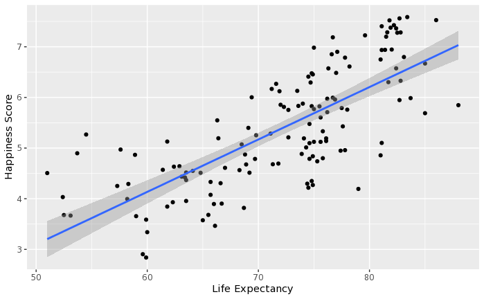

```r
new_table<-life_expect%>%
  select(Country, Year, Life.expectancy, GDP, Schooling)%>%
  filter(Year== 2015)%>%
  inner_join(happiness%>%select(Country,Happiness.Score,Region),
             by = c("Country" = "Country"))
new_table%>%
  ggplot(aes(x=Life.expectancy,y=Happiness.Score)) + geom_point()+
  stat_smooth(method =lm)+
  labs(x="Life Expectancy", y = "Happiness Score")
```

This graph gives me an intuition that life expectancy and happiness are strongly associated and has a positive relationship.

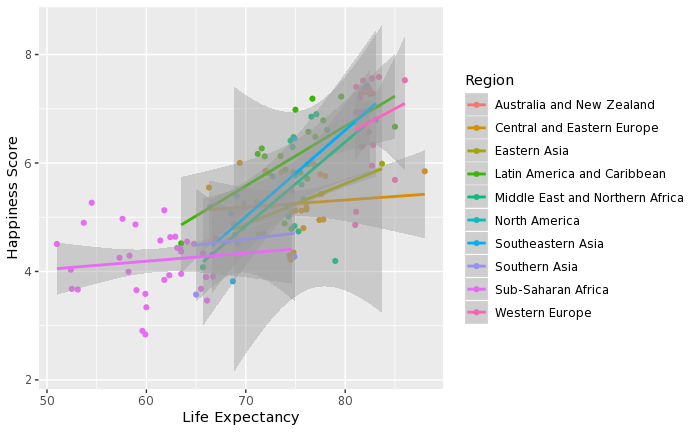

```r
new_table%>%
  ggplot(aes(x=Life.expectancy,y=Happiness.Score,color=Region)) + geom_point()+
  stat_smooth(method =lm)+
  labs(x="Life Expectancy", y = "Happiness Score")
```

### Discover features in the data that may impact modeling decisions

There may be other comfounding variables such as GDP, schooling that will affect happiness scores.